# HW6

2022-11-22

## 1

```r
poke_data <- read.csv("Pokemon.csv")

poke_data<-clean_names(poke_data)

poke_data<-subset(poke_data,type_1 %in% c("Bug","Fire","Grass","Normal","Water","Psychic"))

poke_data$type_1 <- as.factor(poke_data$type_1)

poke_data$legendary <-as.factor(poke_data$legendary)

set.seed(6688)
poke_data_split <- initial_split(poke_data, prop=.7, strata = type_1)

poke_train <- training(poke_data_split)
poke_test <- testing(poke_data_split)

#318 training observations
count(poke_train)
```

```
##     n
## 1 318
```

```r
# 140 testing observations
count(poke_test)
```

```
##     n
## 1 140
```

```r
poke_folds <- vfold_cv(poke_train, v = 5, stata = type_1)

poke_re <- recipe(type_1 ~ legendary + generation+sp_atk+attack+speed+defense+hp+sp_def, data = poke_train) %>% step_dummy(c(legendary,generation)) %>% step_normalize(all_numeric_predictors())
```

## 2

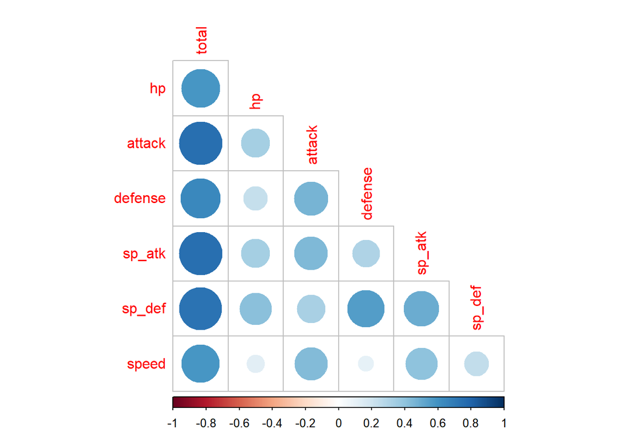

```r
poke_data_cor <- select(poke_data, -c(x,generation))

cor <- cor(select_if(poke_data_cor,is.numeric))

corrplot(cor,diag = FALSE,type = 'lower')
```

To make my correlation matrix, I subset my data set to have only continuous data. every correlation is positive in the plot, with total having the strongest correlations with nearly everything. sp_atk and attack being positively correlated makes sense as wel as sp_def and defense being positively correlated.

## 3

```r
dt <- decision_tree() %>% set_engine("rpart") %>% set_mode("classification")

dt_wf <- workflow() %>% add_model(dt %>% set_args(cost_complexity = tune())) %>% add_formula(type_1 ~ legendary + generation+sp_atk+attack+speed+defense+hp+sp_def)

cc_grid <- grid_regular(cost_complexity(range= c(-3,-1)),levels = 10)
```

```r
tune_res <- tune_grid(dt_wf, resamples = poke_folds, grid = cc_grid, metrics = metric_set(roc_auc) )

save(tune_res, file = "tune_res.rda")
```

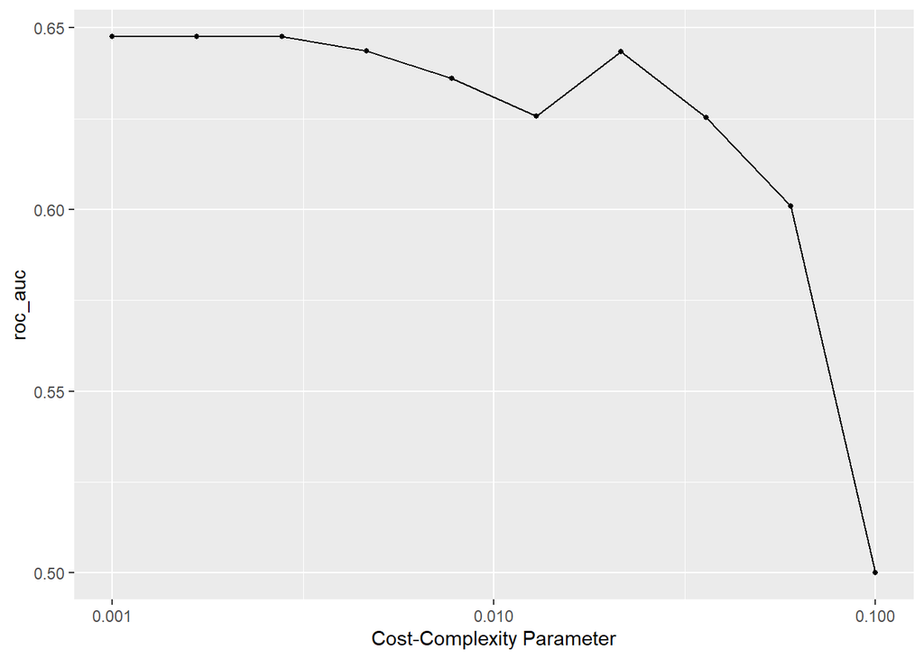

```r
load("tune_res.rda")

autoplot(tune_res)
```

The single decision tree seems to preform best with little to no cost complexity, meaning the tree is free to go with little or no pruning.

## 4

```r
metrics_dt <-collect_metrics(tune_res) %>% arrange()
metrics_dt
```

```
## # A tibble: 10 × 7
##    cost_complexity .metric .estimator  mean     n std_err .config
##              <dbl> <chr>   <chr>      <dbl> <int>   <dbl> <chr>
##  1         0.001   roc_auc hand_till  0.648     5  0.0258 Preprocessor1_Model01
##  2         0.00167 roc_auc hand_till  0.648     5  0.0258 Preprocessor1_Model02
##  3         0.00278 roc_auc hand_till  0.648     5  0.0258 Preprocessor1_Model03
##  4         0.00464 roc_auc hand_till  0.644     5  0.0231 Preprocessor1_Model04
##  5         0.00774 roc_auc hand_till  0.636     5  0.0257 Preprocessor1_Model05
##  6         0.0129  roc_auc hand_till  0.626     5  0.0206 Preprocessor1_Model06
##  7         0.0215  roc_auc hand_till  0.644     5  0.0271 Preprocessor1_Model07
##  8         0.0359  roc_auc hand_till  0.625     5  0.0117 Preprocessor1_Model08
##  9         0.0599  roc_auc hand_till  0.601     5  0.0285 Preprocessor1_Model09
## 10         0.1     roc_auc hand_till  0.5       5  0      Preprocessor1_Model10
```

```r
roc_dt <- metrics_dt[1,4]
```

The best pruned tree was a 3 way tie with an roc of .6476, this was for cost complexity of .0010, .0017, and .0028.

## 5A

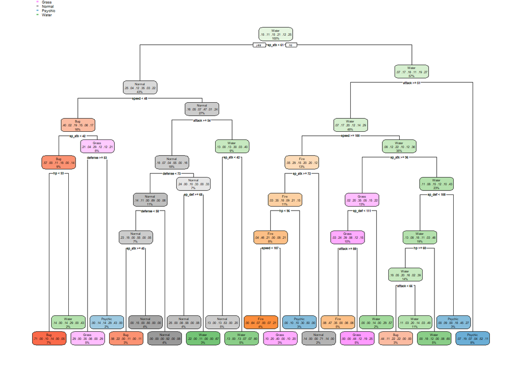

```r
best_cp <- select_best(tune_res)

dt_wf_f <- finalize_workflow(dt_wf,best_cp)

dt_wf_f_fit <- fit(dt_wf_f, data = poke_train)

dt_wf_f_fit %>% extract_fit_engine() %>% rpart.plot()
```

## 5B

```r
rf <- rand_forest() %>% set_engine("ranger", importance = "impurity") %>% set_mode("classification")

rf_wf <- workflow() %>% add_model(rf %>% set_args(mtry = tune(), trees = tune(),min_n = tune())) %>% add_formula(type_1 ~ legendary + generation+sp_atk+attack+speed+defense+hp+sp_def)

rand_grid <- grid_regular(mtry(range= c(1,8)), trees(range = c(1,1000)), min_n(range = c(2,10)),levels = 8)
```

if mtry equals 8 we will be essential just doing bagging since there is no subset of predictors.

## 6

```r
tune_rand <- tune_grid(rf_wf, resamples = poke_folds, grid = rand_grid, metrics = metric_set(roc_auc) )

save(tune_rand,file = "tune_rand.rda")
```

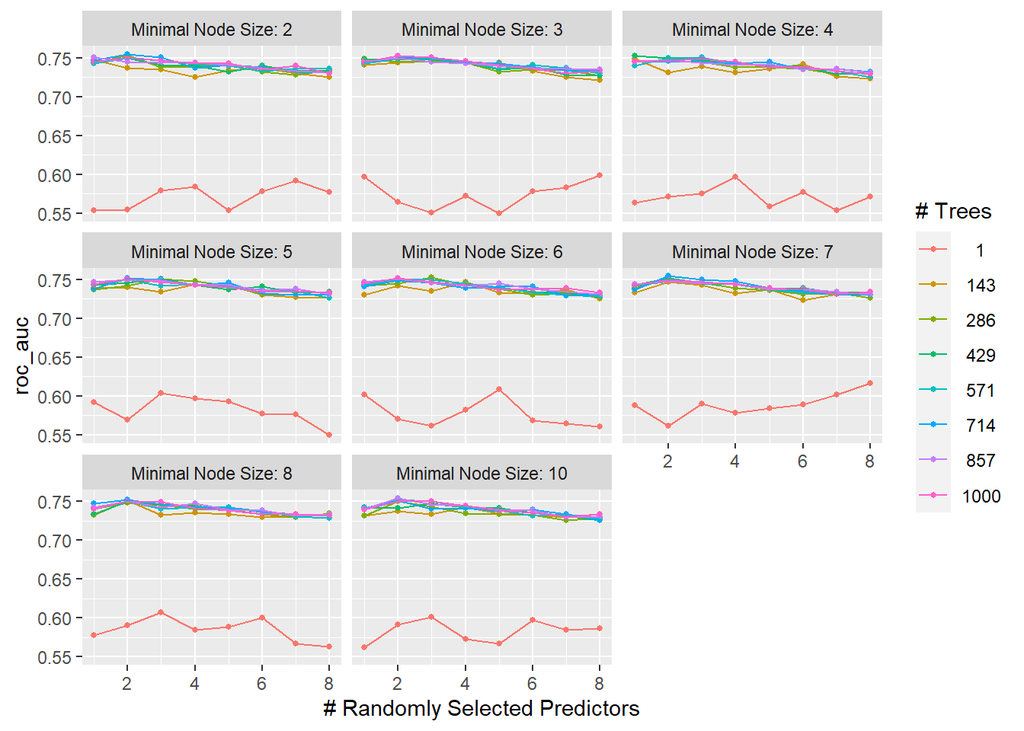

```r
load(file = "tune_rand.rda")

autoplot(tune_rand)
```

```r
metrics_rand <- collect_metrics(tune_rand) %>% arrange(desc(mean))
metrics_rand
```

```
## # A tibble: 512 × 9
##     mtry trees min_n .metric .estimator  mean     n std_err .config
##    <int> <int> <int> <chr>   <chr>      <dbl> <int>   <dbl> <chr>
##  1     2   714     2 roc_auc hand_till  0.754     5  0.0275 Preprocessor1_Model…
##  2     2   714     7 roc_auc hand_till  0.754     5  0.0248 Preprocessor1_Model…
##  3     2   857    10 roc_auc hand_till  0.754     5  0.0259 Preprocessor1_Model…
##  4     2   286     2 roc_auc hand_till  0.754     5  0.0263 Preprocessor1_Model…
##  5     3   286     6 roc_auc hand_till  0.753     5  0.0233 Preprocessor1_Model…
##  6     2  1000     3 roc_auc hand_till  0.752     5  0.0271 Preprocessor1_Model…
##  7     1   429     4 roc_auc hand_till  0.752     5  0.0226 Preprocessor1_Model…
##  8     2   571    10 roc_auc hand_till  0.752     5  0.0238 Preprocessor1_Model…
##  9     2   714     8 roc_auc hand_till  0.752     5  0.0254 Preprocessor1_Model…
## 10     2   714     5 roc_auc hand_till  0.752     5  0.0247 Preprocessor1_Model…
## # … with 502 more rows
```

```r
roc_rand <- metrics_rand[1,6]
```

The best preforming forest had 714 trees 2 randomly selected predictors and a minimum of 2 to split, it produced an AOC of .7545.

## 7

```r
best_forest <- select_best(tune_rand)
roc_rand
```

```
## # A tibble: 1 × 1
##    mean
##   <dbl>
## 1 0.754
```

```r
rf_wf_f <- finalize_workflow(rf_wf,best_forest)

rf_wf_f_fit <- fit(rf_wf_f, data = poke_train) %>% extract_fit_parsnip()
```

## 7

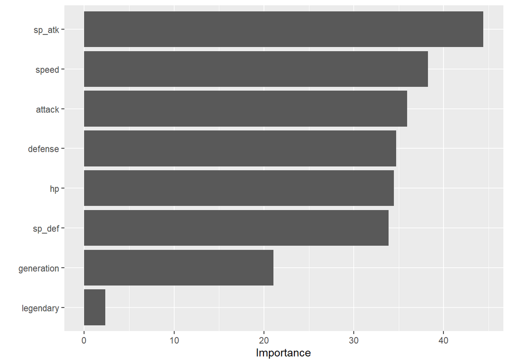

```r
vip(rf_wf_f_fit)
```

Special Attack was the most important with 40%, most other variables fall around 30% with the lowest being generation with around 20% and legendary being about 2 percent. I am a little surprised that special attack was the most important variable but it is possible that a few classes can be easily distinguished by their special attack. I am a little surprised that legendary has so little importance.

## 9

```r
bt <- boost_tree() %>% set_engine("xgboost") %>% set_mode("classification")

bt_wf <- workflow() %>% add_model(bt %>% set_args(trees = tune())) %>% add_formula(type_1 ~ legendary + generation+sp_atk+attack+speed+defense+hp+sp_def)

tree_grid <- grid_regular(trees(range= c(10,2000)),levels = 10)
```

```r
tune_tree <- tune_grid(bt_wf, resamples = poke_folds, grid = tree_grid, metrics = metric_set(roc_auc) )

save(tune_tree, file = "tune_tree.rda")
```

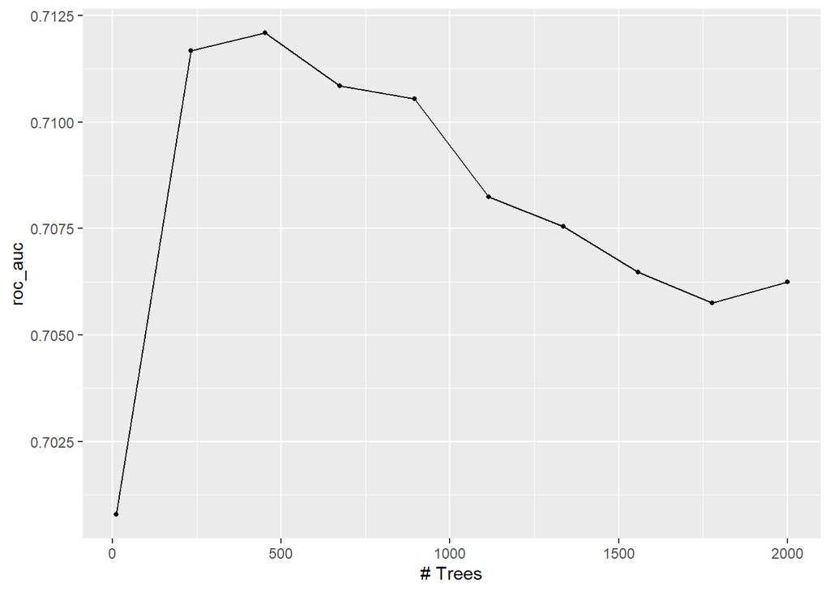

```r
load("tune_tree.rda")
autoplot(tune_tree)
```

```r
metrics_boost <- collect_metrics(tune_tree) %>% arrange(desc(mean))
metrics_boost
```

```
## # A tibble: 10 × 7
##    trees .metric .estimator  mean     n std_err .config
##    <int> <chr>   <chr>      <dbl> <int>   <dbl> <chr>
##  1   452 roc_auc hand_till  0.712     5  0.0238 Preprocessor1_Model03
##  2   231 roc_auc hand_till  0.712     5  0.0239 Preprocessor1_Model02
##  3   673 roc_auc hand_till  0.711     5  0.0242 Preprocessor1_Model04
##  4   894 roc_auc hand_till  0.711     5  0.0236 Preprocessor1_Model05
##  5  1115 roc_auc hand_till  0.708     5  0.0238 Preprocessor1_Model06
##  6  1336 roc_auc hand_till  0.708     5  0.0232 Preprocessor1_Model07
##  7  1557 roc_auc hand_till  0.706     5  0.0235 Preprocessor1_Model08
##  8  2000 roc_auc hand_till  0.706     5  0.0231 Preprocessor1_Model10
##  9  1778 roc_auc hand_till  0.706     5  0.0232 Preprocessor1_Model09
## 10    10 roc_auc hand_till  0.701     5  0.0296 Preprocessor1_Model01
```

```r
roc_boost <- metrics_boost[1,4]
```

452 trees preforms best with boosted trees with an AOC of .7121.

## 10

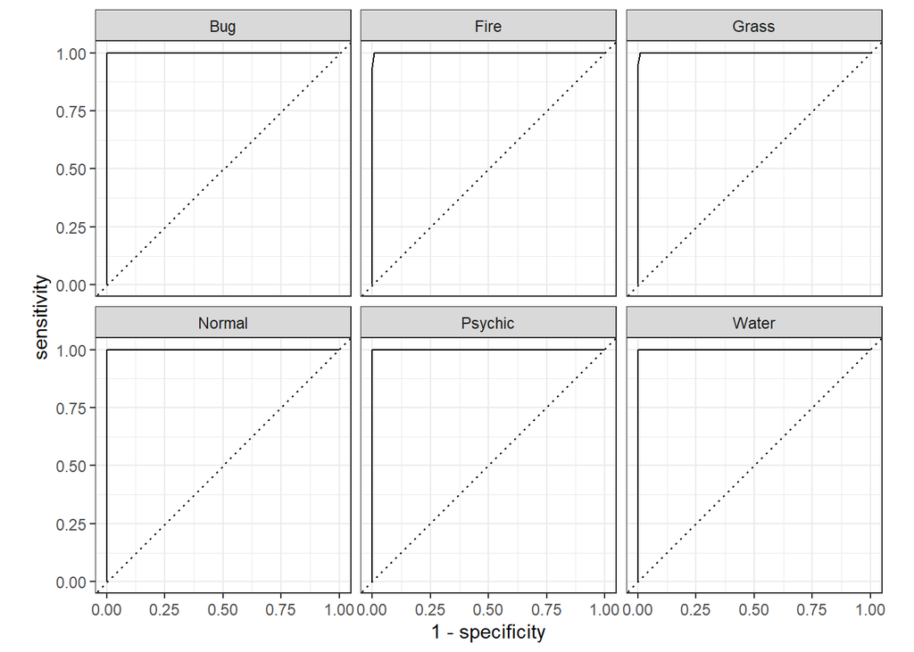

```r
roc <- data.frame(roc_dt,roc_rand,roc_boost)

test_fit <- fit(rf_wf_f,poke_test)

pred_res <- augment(test_fit, poke_test)

roc_curve(pred_res, type_1, .pred_Bug:.pred_Water) %>% autoplot()
```

```r
roc_auc(pred_res,type_1,.pred_Bug:.pred_Water)
```

```
## # A tibble: 1 × 3
##   .metric .estimator .estimate
##   <chr>   <chr>          <dbl>
## 1 roc_auc hand_till       1.00
```

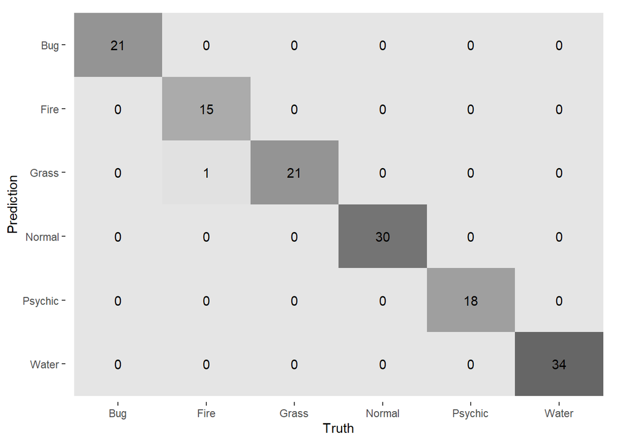

```r
conf_mat(pred_res,truth = type_1, estimate = .pred_class) %>% autoplot(type = "heatmap")
```